# Temporal trends in mortality and readmission after acute heart failure : A systematic review and meta-regression in the past four decades

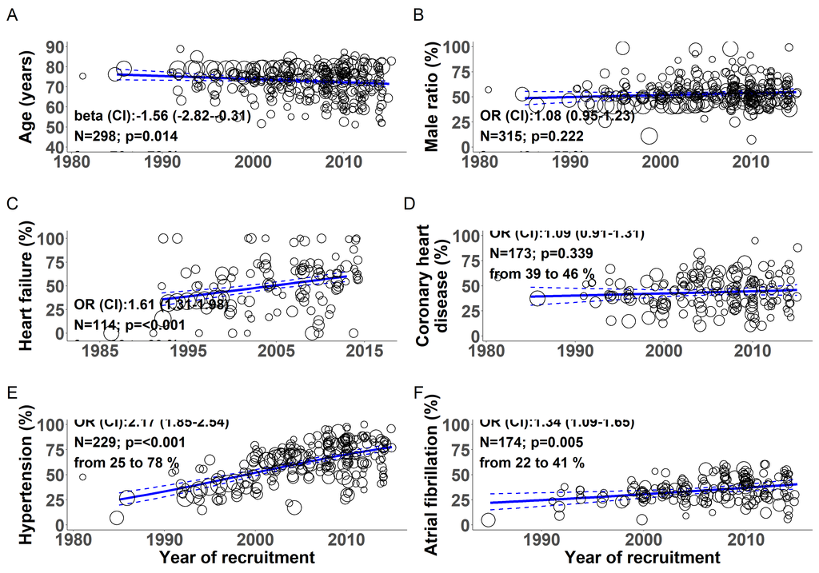

Figure 1

```r
HF_plot <- HF_recruit[[2]] + scale_x_continuous(breaks = c(1985,1995,2005, 2015), limits = c(1983,2017)) # changing spacing in x labels
fig1 <- (Age_recruit[[2]] + SR_recruit[[2]])/
        (HF_plot + CHD_recruit[[2]])/
        (hta_recruit[[2]] + afib_recruit[[2]]) +
        plot_annotation(tag_levels = 'A')  & theme(plot.tag = element_text(size = 30))
fig1
```

```r
ggsave("figures/Fig_1_trends_CVhist.tiff", width = 40, height = 60, units = "cm", dpi = 300)
```

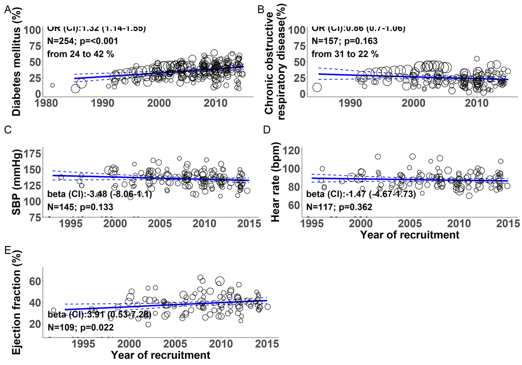

Figure S2

```r
figS2 <- (diab_recruit[[2]] + CORD_recruit[[2]])/
        (SBP_recruit[[2]] + HR_recruit[[2]])/
        (EF_recruit[[2]] + plot_spacer()) +
        plot_annotation(tag_levels = 'A')  & theme(plot.tag = element_text(size = 30))
figS2
```

```r
ggsave("figures/Fig_S2_trends_baseline.tiff", width = 40, height = 60, units = "cm", dpi = 300)
ggsave("figures/Fig_S2_trends_baseline.jpg", width = 40, height = 60, units = "cm", dpi = 300)
```

# Primary outcomes: AHF-related all-cause death and readmission rates

## Overall effect sizes

```r
# 30 day death rate
d30d_rate <- rate_ES("death_30_all")
```

```r
# one-year death rate
d1y_rate <- rate_ES("death_365")
```

```r
# 30-day readmission rate
r30d_rate <- rate_ES("rehosp_30_all.cause_all")
```

```r
# 1-year readmission rate
r1y_rate <- rate_ES("rehosp_365")
```

```r
tab_rate <- bind_rows(d30d_rate[[1]], d1y_rate[[1]], r30d_rate[[1]], r1y_rate[[1]]) %>% mutate(Outcome = c("30-day death", "one-year death", "30-day readmission", "one-year readmission")) %>% dplyr::select(5, 1:4)


tab_rate_flex <- flextable(tab_rate) %>%
      set_caption("Meta-analytic means of 30-day and one-year all-cause death and readmision rates") %>%
      theme_booktabs() %>%
      bold(part = "header") %>%
      align(j = c(2:5), align = "center", part = "all") %>%
      align(j = 1, align = "left", part = "all") %>%
      autofit()

tab_rate_flex %>% width(width = dim(.)$widths * 10 / sum(dim(.)$widths)) # setting column width for a maximum width of 10 inches
```

Meta-analytic means of 30-day and one-year all-cause death and readmision rates

| Outcome | N | Estimate (%) | 95% CI | I^2 |
| --- | --- | --- | --- | --- |
| 30-day death | 148 | 7 | (6 - 8) | 100 |
| one-year death | 204 | 24 | (23 - 26) | 100 |
| 30-day readmission | 108 | 18 | (16 - 19) | 100 |
| one-year readmission | 61 | 46 | (41 - 51) | 100 |

## Effect of recruitment year on AHF-related outcomes

```r
# 30-day death rate
d30d_recruit <- MA_prop_plot("number_follow_up","TIME", "death_30_all", seq(from = 1990, to = 2017, by = 1), "", "death \n%", c(0,65), "30-day", 0.8)

# one-year death rate
d1y_recruit <- MA_prop_plot("number_follow_up", "TIME", "death_365", seq(from = 1985, to = 2017, by = 1), "", "%", c(0,75), "one-year", 0.8)

# 30-day readmission rate
r30d_recruit <- MA_prop_plot("number_follow_up", "TIME", "rehosp_30_all.cause_all", seq(from = 1990, to = 2017, by = 1), "Year of recruitment", "readmission \n%", c(0,65), "", 0.8)

# one-year readmission rate
r1y_recruit <- MA_prop_plot("number_follow_up", "TIME", "rehosp_365", seq(from = 1990, to = 2017, by = 1), "Year of recruitment", "%", c(0,100), "", 0.85)
```

```r
OR_time_tab <- data.frame(Outcome = c("30-day death", "One-year death", "30-day readmission", "One-year readmission"),
           "OR (CI)" = c(d30d_recruit[[3]][[1]], d1y_recruit[[3]][[1]], r30d_recruit[[3]][[1]], r1y_recruit[[3]][[1]]),
                           "P-value" = round(c(d30d_recruit[[3]]$pval, d1y_recruit[[3]]$pval, r30d_recruit[[3]]$pval, r1y_recruit[[3]]$pval),3), check.names = FALSE)

OR_time_tab_flx <-  flextable(OR_time_tab) %>%
          autofit() %>%
          set_caption("Odds ratios and p-values for the effect of year of recruitment (10 yr increment) on the outcomes") %>%
          bold(part = "header") %>%
          align(j = c(1), align = "left", part = "all") %>%
          align(j = c(2,3), align = "left", part = "all")

OR_time_tab_flx %>% width(width = dim(.)$widths * 10 / sum(dim(.)$widths)) # setting column width for a maximum width of 10 inches
```

Odds ratios and p-values for the effect of year of recruitment (10 yr increment) on the outcomes

| Outcome | OR (CI) | P-value |
| --- | --- | --- |
| 30-day death | 0.74 (0.61-0.91) | 0.004 |
| One-year death | 0.86 (0.77-0.96) | 0.007 |
| 30-day readmission | 1.19 (1.01-1.41) | 0.041 |
| One-year readmission | 0.76 (0.53-1.1) | 0.143 |

## Figure 2: Trends of recruitment year for AHF-related outcomes

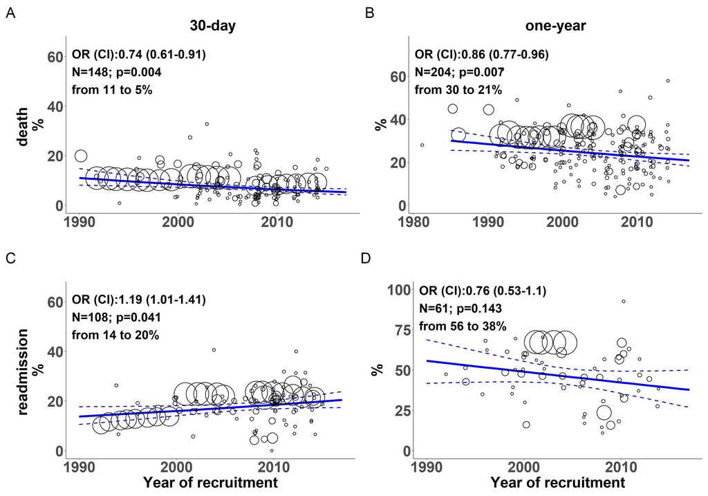

```r
fig2 <- (d30d_recruit[[2]] + d1y_recruit[[2]]) / (r30d_recruit[[2]] + r1y_recruit[[2]]) + plot_annotation(tag_levels = 'A') &
  theme(plot.tag = element_text(size = 30))
fig2
```

```r
ggsave("figures/Fig_2_trend_outcomes.tiff", width = 40, height = 40, units = "cm", dpi = 300)
```

The negative temporal trend remained after removing influential points for 30-day and one-year all-cause deaths. However, for 30-day readmission the positive trend disappeared, while the negative trend for one-year readmission became significant.

## Figure 3 and Table S3: Differences among continents in temporal trends

We are interested to see if the mortality trends over time differ among continents, while considering only studies for which all countries involved were on the same continent.

```r
DATA %>% filter(multicontinent == "No" | is.na(multicontinent)) %>%
              group_by(continent) %>%
              count() %>% flextable() %>% autofit()
```

| continent | n |
| --- | --- |
| Africa | 5 |
| Asia | 53 |
| Europe | 118 |
| North_America | 132 |
| Oceania | 9 |
| South_America | 2 |
|  | 1 |

For Africa, Oceania and South America, there are too few studies to investigate temporal trends, so we’ll focus on Asia, Europe and North America.

```r
DATA_cont <- DATA %>%
                  filter((multicontinent == "No" | is.na(multicontinent)) &
                           (continent == "Asia" | continent == "Europe" | continent == "North_America")) %>% droplevels() %>%
              mutate(continent = fct_relevel(as_factor(continent), "Asia"))
```

```r
# 30-day death
mat_cont_d30d <- cbind(c(seq(from = 2000, to = 2017, by = 1), seq(from = 1990, to = 2017, by = 1), seq(from = 1995, to = 2017, by = 1)),
      c(rep(0, 18), rep(1,28), rep(0,23)),
      c(rep(0, 46), rep(1,23)),
      c(rep(0, 18), seq(from = 1990, to = 2017, by = 1), rep(0, 23)),
      c(rep(0, 46), seq(from = 1995, to = 2017, by = 1)))

cont_d30d <- sub_OR_cont_fun("number_follow_up","TIME", "death_30_all", "continent", "Europe", "North_America", "30-day death", mat_cont_d30d, "", "death\n(%)", "30-day", c(0,35), 0.9, c(18,28,23))

# one-year death
mat_cont_d1y <- cbind(rep(seq(from = 1985, to = 2017, by = 1),3),
      c(rep(0, 33), rep(1,33), rep(0,33)),
      c(rep(0, 66), rep(1,33)),
      c(rep(0, 33), seq(from = 1985, to = 2017, by = 1), rep(0, 33)),
      c(rep(0, 66), seq(from = 1985, to = 2017, by = 1)))

cont_d1y <- sub_OR_cont_fun("number_follow_up","TIME", "death_365", "continent", "Europe", "North_America", "One-year death", mat_cont_d1y, "", "(%)", "One-year", c(0,67), 0.9, c(33,33,33))

# 30-day readmission

cont_r30d <- sub_OR_cont_fun("number_follow_up","TIME", "rehosp_30_all.cause_all", "continent", "Europe", "North_America", "30-day readmission", mat_cont_d30d, "Year of recruitment", "readmission\n(%)", "", c(0,50), 0.9, c(18,28,23))

# one-year readmission
mat_cont_r1y <- cbind(rep(seq(from = 1995, to = 2017, by = 1),3),
      c(rep(0, 23), rep(1,23), rep(0,23)),
      c(rep(0, 46), rep(1,23)),
      c(rep(0, 23), seq(from = 1995, to = 2017, by = 1), rep(0, 23)),
      c(rep(0, 46), seq(from = 1995, to = 2017, by = 1)))

cont_r1y <- sub_OR_cont_fun("number_follow_up","TIME", "rehosp_365", "continent", "Europe", "North_America", "One-year readmission", mat_cont_r1y, "Year of recruitment", "(%)", "", c(0,100), 0.9, c(23,23,23))

cont_tab <- bind_rows(cont_d30d[[1]], cont_d1y[[1]], cont_r30d[[1]], cont_r1y[[1]])
```

```r
flx_cont_tab <-  cont_tab %>%
                    dplyr::select(c(1:3, 7:9)) %>%
                    flextable() %>%
                    autofit() %>%
                    set_caption("Table S3: Odds-ratios (CI) and p-values for the effects of year of recruitment (10 year increment) on outcomes in relation to continent of origin of AHF studies") %>%
                    bold(part = "header") %>%
                    align(j = c(3:6), align = "center", part = "all") %>%
                    align(j = c(1,2), align = "left", part = "all")

flx_cont_tab %>% width(width = dim(.)$widths * 10 / sum(dim(.)$widths)) # setting column width for a maximum width of 10 inches
```

Table S3: Odds-ratios (CI) and p-values for the effects of year of recruitment (10 year increment) on outcomes in relation to continent of origin of AHF studies

| Variable | Continent | N | OR (95% CI) | p | p inter |
| --- | --- | --- | --- | --- | --- |
| 30-day death |  |  |  |  | 0.2705 |
|  | Asia | 23 | 0.56 (0.3 - 1.05) | 0.0706 |  |
|  | Europe | 48 | 0.67 (0.52 - 0.86) | 0.0015 |  |
|  | North-America | 63 | 0.9 (0.64 - 1.28) | 0.5637 |  |
| One-year death |  |  |  |  | 0.7764 |
|  | Asia | 29 | 0.99 (0.72 - 1.36) | 0.9553 |  |
|  | Europe | 82 | 0.88 (0.74 - 1.06) | 0.1766 |  |
|  | North-America | 75 | 0.87 (0.74 - 1.03) | 0.1153 |  |
| 30-day readmission |  |  |  |  | 0.418 |
|  | Asia | 16 | 0.92 (0.53 - 1.58) | 0.762 |  |
|  | Europe | 49 | 1.17 (0.93 - 1.47) | 0.1798 |  |
|  | North-America | 35 | 1.35 (1.02 - 1.78) | 0.0375 |  |
| One-year readmission |  |  |  |  | 0.0774 |
|  | Asia | 12 | 1.17 (0.44 - 3.08) | 0.7501 |  |
|  | Europe | 23 | 0.4 (0.2 - 0.78) | 0.0075 |  |
|  | North-America | 20 | 0.94 (0.53 - 1.68) | 0.8441 |  |

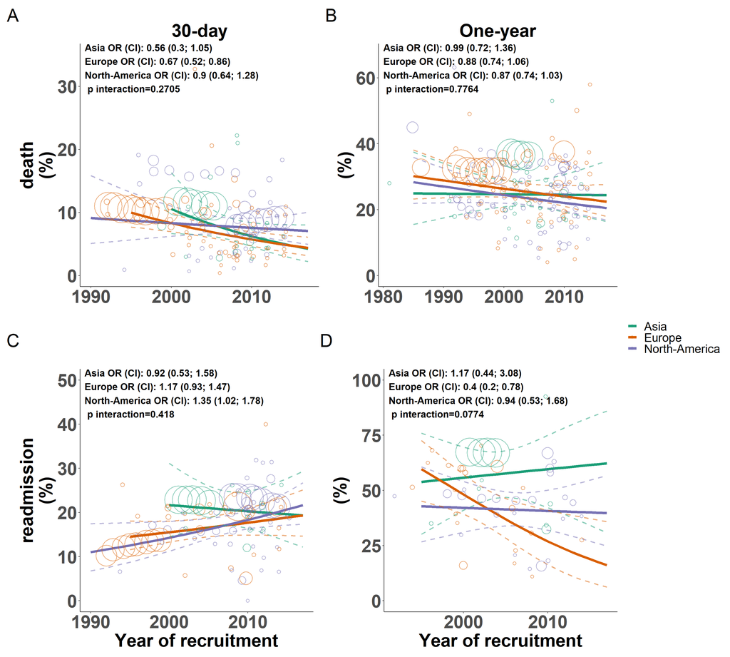

```r
fig_3_cont_inter <- (cont_d30d[[2]] + cont_d1y[[2]]) / (cont_r30d[[2]] + cont_r1y[[2]]) + plot_annotation(tag_levels = 'A') &
  theme(plot.tag = element_text(size = 30), legend.position = "right")
fig_3_cont_inter + plot_layout(guides = "collect")
```

```r
ggsave("figures/Fig_3_inter_cont_time.tiff", width = 40, height = 40, units = "cm", dpi = 300)
```

## Figure S3: Non-linear trends in primary outcomes

We want to check whether the observed temporal trends are indeed linear or if adding a non-linear component improves the fit. As definitions, coding and management of AHF has changed over time, we could expect some non-linear trends reflecting these changes.

```r
# non-linear trends

d30d_recruit_nonlin <- MA_prop_nonlin_plot("number_follow_up","TIME", "death_30_all", seq(from = 1990, to = 2017, by = 1), "", "death \n%", c(0,65), "30-day", 0.8, 3)

d1y_recruit_nonlin <- MA_prop_nonlin_plot("number_follow_up","TIME", "death_365", seq(from = 1985, to = 2017, by = 1), "", "%", c(0,75), "one-year", 0.8, 3)

r30d_recruit_nonlin <- MA_prop_nonlin_plot("number_follow_up","TIME", "rehosp_30_all.cause_all", seq(from = 1990, to = 2017, by = 1), "Year of recruitment", "readmission \n%", c(0,65), "", 0.8, 3)

r1y_recruit_nonlin <- MA_prop_nonlin_plot("number_follow_up","TIME", "rehosp_365", seq(from = 1990, to = 2017, by = 1), "Year of recruitment", "%", c(0,100), "", 0.8, 3)
```

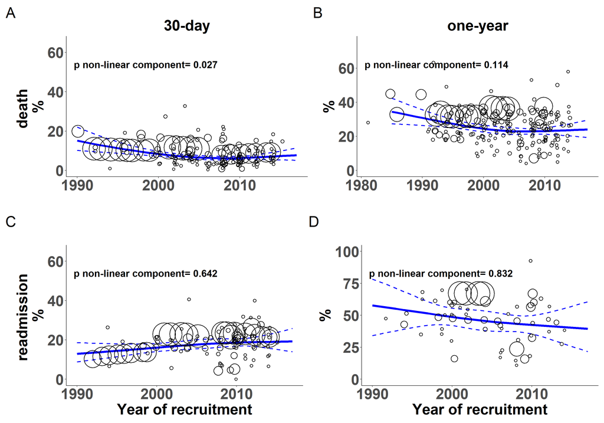

```r
fig_S3_nonlin <- (d30d_recruit_nonlin[[2]] + d1y_recruit_nonlin[[2]]) / (r30d_recruit_nonlin[[2]] + r1y_recruit_nonlin[[2]]) + plot_annotation(tag_levels = 'A') &
  theme(plot.tag = element_text(size = 30))
fig_S3_nonlin
```

```r
ggsave("figures/Fig_S3_nonlinear_trend_outcomes.tiff", width = 40, height = 40, units = "cm", dpi = 300)
ggsave("figures/Fig_S3_nonlinear_trend_outcomes.jpg", width = 40, height = 40, units = "cm", dpi = 300)
```

Adding a non-linear component (i.e. a restricted cubic spline) does not improve model fit for one-year mortality neither for readmission outcomes. For 30-day death, it seems that the decrease was stronger between 1990 and 2000 and then slowed down, but it could also be driven by one study with high mortality from 1990, so we are just going to check if it holds true after removing this study.

```r
dat_30d_noout <- na.omit(DATA[,c("number_follow_up", "death_30_all", "TIME")])
dat_30d_noout <- dat_30d_noout %>% filter(TIME > 1990)
  colnames(dat_30d_noout)<-c("Ni","Ei","X")
  dat_30d_noout$X_div <- dat_30d_noout$X/10

  es_30d_noout <- escalc(
    xi= Ei,
    ni =Ni,
    data = dat_30d_noout,
    measure = "PLO",
    to="if0all")

  #significance test for non-linear component
  mod_lin_ML <- rma(yi=yi, vi=vi, mods= ~X, data=es_30d_noout, method = "ML")
  mod_nonlin_ML <- rma(yi=yi,mods = ~X + rcspline.eval(X, nk = 3,inclx = FALSE), vi=vi, data=es_30d_noout, method = "ML")
  pval <- anova(mod_lin_ML, mod_nonlin_ML)[6]
```

After removing this study the p-value for the non-linear component was 0.045.

## Non-linear trends in primary outcomes within continent

In addition to testing for overall non-linear trends, we also want to check if there are some between-continent differences in the linearity of temporal trends. To do this we compare a model with an interaction allowing non-linear relationships (i.e. with a restricted cubic spline) to a model with an interaction constraining a linear relationship.

```r
tab_nonlin_cont <- data.frame(Outcome = c("30-day death", "one-year death", "30-day readmission", "one-year readmission"),
           "P non-linear interaction" = c(sub_nonlin_cont_fun("number_follow_up", "TIME", "death_30_all", "continent", 3), sub_nonlin_cont_fun("number_follow_up", "TIME", "death_365", "continent", 3), sub_nonlin_cont_fun("number_follow_up", "TIME", "rehosp_30_all.cause_all", "continent", 3), sub_nonlin_cont_fun("number_follow_up", "TIME", "rehosp_365", "continent", 3)),
           check.names = FALSE)

tab_nonlin_cont_flex <- flextable(tab_nonlin_cont) %>%
      set_caption("Tests for non-linear trends in primary outcomes in relation to continent") %>%
      bold(part = "header") %>%
      align(j = c(2), align = "center", part = "all") %>%
      align(j = 1, align = "left", part = "all") %>%
      autofit()

tab_nonlin_cont_flex %>% width(width = dim(.)$widths * 10 / sum(dim(.)$widths)) # setting column width for a maximum width of 10 inches
```

Tests for non-linear trends in primary outcomes in relation to continent

| Outcome | P non-linear interaction |
| --- | --- |
| 30-day death | 0.26 |
| one-year death | 0.10 |
| 30-day readmission | 0.90 |
| one-year readmission | 0.41 |

None of the interactions are significant, showing that adding a non-linear component in the interaction does not improve the models and suggesting that changes in definitions, coding and management did not influence the temporal trends in any continent.

# Association between oral heart failure therapies at admission and AHF-related outcomes

## Figure 4: Temporal trends of reported rates of oral heart failure therapies at admission

```r
# ACEi and/or ARB (RAASi)
ACEi_recruit_adm <- wtlogis_plot("number_ttt", "TIME", "all_ACE_ARB_adm_n", seq(from = 1990, to = 2017, by = 1), "", "RAASi (%)", c(0,100), "", 0.15, "%")

# Diuretics
diur_recruit_adm <- wtlogis_plot("number_ttt", "TIME", "A_all_diuretic_n", seq(from = 1990, to = 2017, by = 1), "Year of recruitment", "Diuretics (%)", c(0,100), "", 0.15, "%")

# Beta-blockers
BB_recruit_adm <- wtlogis_plot("number_ttt", "TIME", "A_all_B_n", seq(from = 1990, to = 2017, by = 1), "", "Beta-blocker (%)", c(0,120), "", 0.8, "%")

# Digoxin
digo_recruit_adm <- wtlogis_plot("number_ttt", "TIME", "A_all_digoxin_n", seq(from = 1990, to = 2017, by = 1), "Year of recruitment", "Digoxin (%)", c(0,100), "", 0.8, "%")
```

Here we represent weighted logistic regressions with log(study size) as weights.

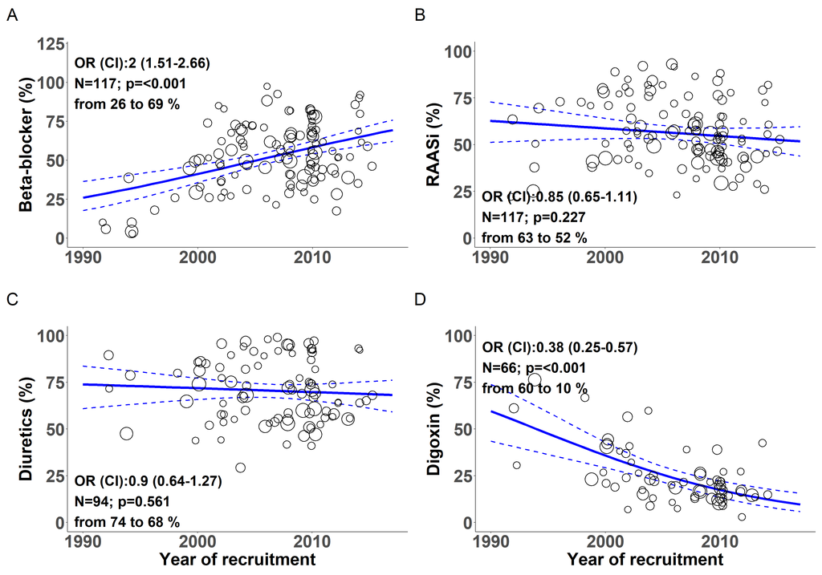

```r
fig4 <- (BB_recruit_adm[[2]] + ACEi_recruit_adm[[2]])/ (diur_recruit_adm[[2]] + digo_recruit_adm[[2]]) + plot_annotation(tag_levels = 'A')  & theme(plot.tag = element_text(size = 30))
fig4
```

```r
ggsave("figures/Fig_4_trend_therapies.tiff", width = 40, height = 40, units = "cm", dpi = 300)
```

```r
OR_tt_time_tab <- data.frame(Outcome = c("RAASi", "Diuretics", "Beta-blockers", "Digoxin"),
           "OR (CI)" = c(ACEi_recruit_adm[[3]][[1]], diur_recruit_adm[[3]][[1]], BB_recruit_adm[[3]][[1]], digo_recruit_adm[[3]][[1]]),
                           "P-value" = c(ACEi_recruit_adm[[3]][[2]], diur_recruit_adm[[3]][[2]], BB_recruit_adm[[3]][[2]], digo_recruit_adm[[3]][[2]]), check.names = FALSE)

OR_tt_time_tab_flx <-  flextable(OR_tt_time_tab) %>%
          autofit() %>%
          set_caption("Odds ratios and p-values for the effect of year of recruitment (10 yr increment) on treatment prescriptions") %>%
          bold(part = "header") %>%
          align(j = c(1), align = "left", part = "all") %>%
          align(j = c(2,3), align = "left", part = "all")

OR_tt_time_tab_flx %>% width(width = dim(.)$widths * 10 / sum(dim(.)$widths)) # setting column width for a maximum width of 10 inches
```

Odds ratios and p-values for the effect of year of recruitment (10 yr increment) on treatment prescriptions

| Outcome | OR (CI) | P-value |
| --- | --- | --- |
| RAASi | 0.85 (0.65-1.11) | 0.227 |
| Diuretics | 0.9 (0.64-1.27) | 0.561 |
| Beta-blockers | 2 (1.51-2.66) | <0.001 |
| Digoxin | 0.38 (0.25-0.57) | <0.001 |

## Table S4: Summary table for the effect of oral heart failure therapies at admission on 30-day death

```r
# getting treatment prescription rates on a percentage scale
DATA <- DATA %>% mutate(ACE_ARB_admrate_100 = all_ACE_ARB_adm_rate *100,
                        BB_admrate_100 = A_all_B_rate * 100,
                        diur_admrate_100 = A_all_diuretic_rate * 100,
                        digox_admrate_100 = A_all_digoxin_rate * 100)

## Effects of oral heart failure therapies on 30-day death

## In the MA_prop_plot_adj function, the figure produced is only adjusted in year of recruitment but OR are calculated in two ways: while further adjusting on other variables depending on sample sizes (fourth element) or not (fifth element)

# ACEi and/or ARB (RAASi)
admACEi_death_30d <- MA_prop_plot_adj("number_follow_up", "ACE_ARB_admrate_100", "TIME", "type_Obsv_0_trial_1", "mono0_multi1", "death_30_all", seq(from = 20, to = 90, by = 5), 2003, "RAASi (%)", "30-day death (%)", c(0,40), "", 0.8)
# adjusted on study type and mono vs multicentric

# Diuretics
admdiur_death_30d <- MA_prop_plot_adj("number_follow_up", "diur_admrate_100", "TIME", "type_Obsv_0_trial_1", "mono0_multi1", "death_30_all", seq(from = 30, to = 100, by = 5), 2003, "Diuretics (%)", "30-day death (%)", c(0,40), "", 0.8)
# not adjusted

# Beta-blockers
admBB_death_30d <- MA_prop_plot_adj("number_follow_up", "BB_admrate_100", "TIME", "type_Obsv_0_trial_1", "mono0_multi1", "death_30_all", seq(from = 10, to = 100, by = 5), 2003, "Beta-blocker (%)", "30-day death (%)", c(0,40), "", 0.8)
# adjusted on study type and mono vs mutlicentric

# Digoxin
admdigo_death_30d <- MA_prop_plot_adj("number_follow_up", "digox_admrate_100", "TIME", "type_Obsv_0_trial_1", "mono0_multi1", "death_30_all", seq(from = 5, to = 60, by = 5), 2003,  "Digoxin (%)", "30-day death (%)", c(0,40), "", 0.8)
# not adjusted
```

```r
summ_ttt_adm <- data.frame(Treatment = c("RAASi", "Diuretics", "Beta-blockers", "Digoxin"),
                           "OR (CI) " = c(admACEi_death_30d[[5]][[1]], admdiur_death_30d[[5]][[1]], admBB_death_30d[[5]][[1]], admdigo_death_30d[[5]][[1]]),
                           "P-value " = round(c(admACEi_death_30d[[5]]$pval, admdiur_death_30d[[5]]$pval, admBB_death_30d[[5]]$pval, admdigo_death_30d[[5]]$pval),3), check.names = FALSE)

typo_adm <- data.frame(col_keys = colnames(summ_ttt_adm),
                       type = c("", rep("30-day death", 2)),
                       col = c("Treatment", "OR (CI)", "P-value"), stringsAsFactors = FALSE)

flx_summ_ttt_adm <-  flextable(summ_ttt_adm) %>%
                    autofit() %>%
                    set_caption("Table S4: Odds-ratio (CI) and p-value for the effects of oral heart failure therapies at admission on 30-day all-cause death") %>%
                    set_header_df(mapping = typo_adm, key = "col_keys") %>%
                    merge_h(part = "header") %>%
                    merge_v(part = "header") %>%
                    theme_booktabs() %>%
                    bold(part = "header") %>%
                    align(j = c(2:3), align = "center", part = "all") %>%
                    align(j = 1, align = "left", part = "all") %>%
                    add_footer(`Treatment` = "For all analyses, year of recruitment was added as a moderator.") %>%
                   merge_at(j = 1:3, part = "footer")

flx_summ_ttt_adm %>% width(width = dim(.)$widths * 10 / sum(dim(.)$widths)) # setting column width for a maximum width of 10 inches
```

Table S4: Odds-ratio (CI) and p-value for the effects of oral heart failure therapies at admission on 30-day all-cause death

| Treatment | 30-day death OR (CI) | 30-day death P-value |
| --- | --- | --- |
| RAASi | 0.8 (0.7-0.91) | 0.001 |
| Diuretics | 1 (0.86-1.16) | 0.995 |
| Beta-blockers | 0.9 (0.81-0.99) | 0.033 |
| Digoxin | 1.03 (0.77-1.37) | 0.888 |

For all analyses, year of recruitment was added as a moderator.

Odds-ratio are calculated using a 10% increment of cardiovascular treatments.

## Figure 5: Meta-regression for the effect of oral heart failure therapies prescribed at admission on 1-year all-cause death

```r
## Effects of cardiovascular treatments on 1-year death

## In the MA_prop_plot_adj function, the figure produced is only adjusted in year of recruitment but OR are calculated in two ways: while further adjusting on other variables depending on sample sizes (fourth element) or not (fifth element)

# ACEi and/or ARB (RAASi)
admACEi_death_1y <- MA_prop_plot_adj("number_follow_up", "ACE_ARB_admrate_100", "TIME", "type_Obsv_0_trial_1", "mono0_multi1", "death_365", seq(from = 20, to = 90, by = 5), 2003, "RAASi (%)", "", c(0,70), "", 0.9)
# adjusted on study type and mono vs multicentric

# Diuretics
admdiur_death_1y <- MA_prop_plot_adj("number_follow_up", "diur_admrate_100", "TIME", "type_Obsv_0_trial_1", "mono0_multi1", "death_365", seq(from = 30, to = 100, by = 5), 2003, "Diuretics (%)", "One-year death (%)", c(0,70), "", 0.9)
# adjusted on mono vs multicentric

# Beta-blockers
admBB_death_1y <- MA_prop_plot_adj("number_follow_up", "BB_admrate_100", "TIME","type_Obsv_0_trial_1", "mono0_multi1", "death_365", seq(from = 10, to = 100, by = 5), 2003, "Beta-blocker (%)", "One-year death (%)", c(0,70), "", 0.9)
# adjusted on mono vs multicentric

# Digoxin
admdigo_death_1y <- MA_prop_plot_adj("number_follow_up", "digox_admrate_100", "TIME", "type_Obsv_0_trial_1", "mono0_multi1", "death_365", seq(from = 5, to = 60, by = 5), 2003,  "Digoxin (%)", "", c(0,70), "",0.9)
# adjusted on mono vs multicentric
```

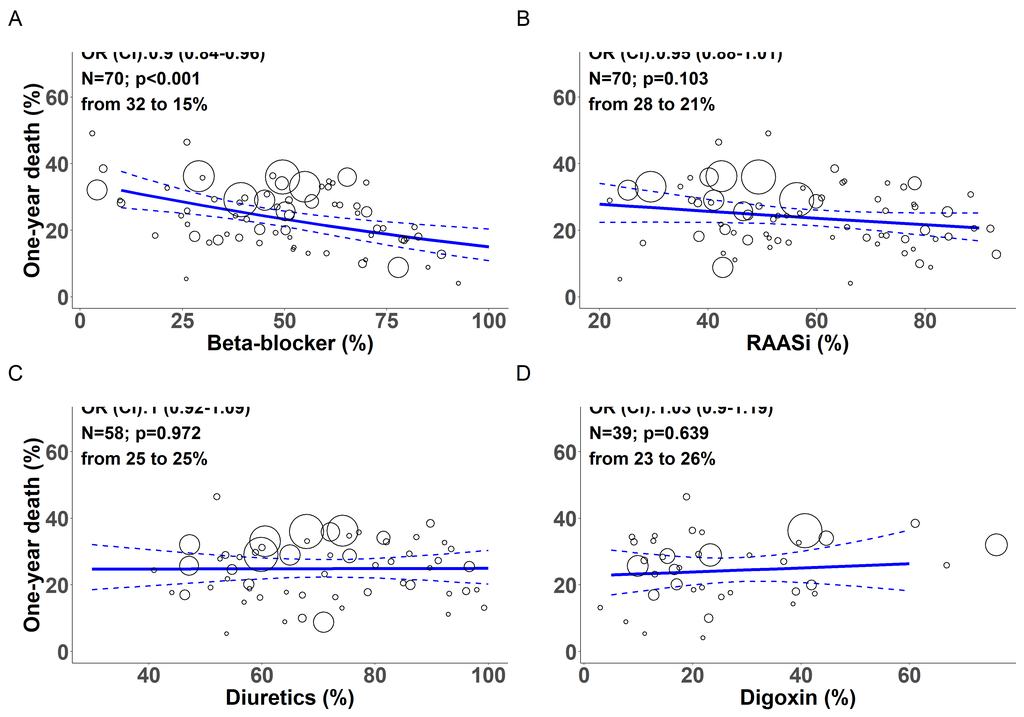

```r
fig5 <- (admBB_death_1y[[3]] +admACEi_death_1y[[3]])/(admdiur_death_1y[[3]] + admdigo_death_1y[[3]]) + plot_annotation(tag_levels = 'A') & theme(plot.tag = element_text(size = 30))
fig5
```

For those analyses we also added year of recruitment as a moderator, model predictions are shown for a median year of 2003.

```r
ggsave("figures/Fig_5_therapies_1yrdeath.tiff", width = 40, height = 40, units = "cm", dpi = 100)
```

## Table S5: Combined effect of RAASi and beta-blockers at admission on 30-day and one-year death

For these analyses, we created a four-class variable describing the combination of high and low (i.e. above and below the median, respectively) percentages of prescription of RAASi and beta-blockers.

```r
# getting median values of percentage of RAASi (ACE/ARB) and beta-blockers prescriptions at admission
med_ACE_adm_1y <- median(na.omit(DATA[,c("death_365","ACE_ARB_admrate_100")])$ACE_ARB_admrate_100)
med_BB_adm_1y <- median(na.omit(DATA[,c("death_365","BB_admrate_100")])$BB_admrate_100)
med_ACE_adm_30d <- median(na.omit(DATA[,c("death_30_all","ACE_ARB_admrate_100")])$ACE_ARB_admrate_100)
med_BB_adm_30d <- median(na.omit(DATA[,c("death_30_all","BB_admrate_100")])$BB_admrate_100)

DATA <- DATA %>%
  mutate(ACE_bin_1y = ifelse(ACE_ARB_admrate_100 > med_ACE_adm_1y, "high RAASi", "low RAASi"),
                        BB_bin_1y = ifelse(BB_admrate_100 > med_BB_adm_1y, "high BBs", "low BBs"),
                        ACE_bin_30d = ifelse(ACE_ARB_admrate_100 > med_ACE_adm_30d, "high RAASi", "low RAASi"), BB_bin_30d = ifelse(BB_admrate_100 > med_BB_adm_30d, "high BBs", "low BBs")) %>%
                mutate(ACE_BB_1ycat = fct_relevel(as_factor(ifelse(ACE_bin_1y == "high RAASi" & BB_bin_1y == "high BBs", "high RAASi\n& high BBs",
                                  ifelse(ACE_bin_1y == "high RAASi" & BB_bin_1y == "low BBs", "high RAASi\n& low BBs",
                                  ifelse(ACE_bin_1y == "low RAASi" & BB_bin_1y == "high BBs", "low RAASi\n& high BBs", "low RAASi\n& low BBs")))), "low RAASi\n& low BBs", "high RAASi\n& low BBs", "low RAASi\n& high BBs"),
                       ACE_BB_30dcat = fct_relevel(as_factor(ifelse(ACE_bin_30d == "high RAASi" & BB_bin_30d == "high BBs", "high RAASi\n& high BBs",
                                  ifelse(ACE_bin_30d == "high RAASi" & BB_bin_30d == "low BBs", "high RAASi\n& low BBs",
                                  ifelse(ACE_bin_30d == "low RAASi" & BB_bin_30d == "high BBs", "low RAASi\n& high BBs", "low RAASi\n& low BBs")))), "low RAASi\n& low BBs", "high RAASi\n& low BBs", "low RAASi\n& high BBs"))
```

```r
## for 30-day death
OR_ACE_BB_d30d <- data.frame(Group = as_factor(levels(DATA$ACE_BB_30dcat)),
                             N = rep(NA,4),
                             Nval = rep(NA,4),
                             Group_N = rep(NA, 4),
                             logOdds = rep(NA,4),
                             lowCI = rep(NA,4),
                             upCI = rep(NA,4),
                             OR_CI = rep(NA,4),
                             p = rep(NA,4),
                             pval = rep(NA,4),
                            check.names = FALSE)

DAT_ACE_BB_30dcat <- na.omit(DATA[,c("number_follow_up", "death_30_all", "ACE_BB_30dcat")])

OR_ACE_BB_d30d$N <- paste0("N=",table(DAT_ACE_BB_30dcat$ACE_BB_30dcat))
OR_ACE_BB_d30d$Nval <- table(DAT_ACE_BB_30dcat$ACE_BB_30dcat)
OR_ACE_BB_d30d$Group_N <- as_factor(paste0(OR_ACE_BB_d30d$Group,"\n", OR_ACE_BB_d30d$N))

es_ACE_BB_30dcat <- escalc(
  xi= death_30_all,
  ni = number_follow_up,
  data = DAT_ACE_BB_30dcat,
  measure = "PLO",
  to="if0all")

# model to get estimates
full_ACE_BB_30dcat <- rma(yi = yi, vi = vi, mods = ~ACE_BB_30dcat, data = es_ACE_BB_30dcat, method = "REML")

OR_ACE_BB_d30d$logOdds <- c(0, full_ACE_BB_30dcat$b[-1])
OR_ACE_BB_d30d$lowCI <- c(0, full_ACE_BB_30dcat$ci.lb[-1])
OR_ACE_BB_d30d$upCI <- c(0, full_ACE_BB_30dcat$ci.ub[-1])
OR_ACE_BB_d30d$OR_CI <- paste0(round(exp(OR_ACE_BB_d30d$logOdds),2)," (", round(exp(OR_ACE_BB_d30d$lowCI),2)," - ", round(exp(OR_ACE_BB_d30d$upCI),2),")")
OR_ACE_BB_d30d$p <- c(NA, paste0("p=", round(full_ACE_BB_30dcat$pval[-1], 3)))
OR_ACE_BB_d30d$pval <- c(NA, round(full_ACE_BB_30dcat$pval[-1], 3))


#Significance test
full_ACE_BB_30dcat_ML <- rma(yi = yi, vi = vi, mods = ~ACE_BB_30dcat, data = es_ACE_BB_30dcat, method = "ML")
red_ACE_BB_30dcat_ML <- rma(yi = yi, vi = vi, data = es_ACE_BB_30dcat, method = "ML")
ovp_ACE_BB_30dcat <-paste0("Overall p= ", round(anova(full_ACE_BB_30dcat_ML,red_ACE_BB_30dcat_ML)[6]$pval,3))

OR_ACE_BB_30d_plot <- ggplot(data = OR_ACE_BB_d30d, aes(x = Group_N, y = logOdds)) +
          geom_pointrange(aes(ymin = lowCI, ymax = upCI), size = 4) +
          geom_hline(yintercept = 0, linetype = 2) +
          geom_text(aes(y = 0.35, label = p), size = 10) +
          geom_text(aes(x = 1.2, y = -1.1, label = ovp_ACE_BB_30dcat), size = 10) +
          theme_classic() + labs(x = "Treatment group", y = "Log odds (95% CI)", title = "30-day death") +
          theme(axis.title.x = element_text( face="bold", size=35),
               axis.title.y = element_text( face="bold", size=35),
               axis.text.x = element_text(face="bold", size=30),
               axis.text.y = element_text(face="bold", size=30),
               plot.title = element_text(face = "bold",size = 40, hjust = 0.5),
               legend.position = "none")


## for 1 year death
OR_ACE_BB_d1y <- data.frame(Group = as_factor(levels(DATA$ACE_BB_1ycat)),
                             N = rep(NA,4),
                            Nval = rep(NA, 4),
                             Group_N = rep(NA,4),
                             logOdds = rep(NA,4),
                             lowCI = rep(NA,4),
                             upCI = rep(NA,4),
                             OR_CI = rep(NA,4),
                             p = rep(NA,4),
                            pval = rep(NA,4),
                            check.names = FALSE)

DAT_ACE_BB_1ycat <- na.omit(DATA[,c("number_follow_up", "death_365", "ACE_BB_1ycat")])

OR_ACE_BB_d1y$N <- paste0("N=",table(DAT_ACE_BB_1ycat$ACE_BB_1ycat))
OR_ACE_BB_d1y$Nval <- table(DAT_ACE_BB_1ycat$ACE_BB_1ycat)
OR_ACE_BB_d1y$Group_N <- as_factor(paste0(OR_ACE_BB_d1y$Group,"\n", OR_ACE_BB_d1y$N))

es_ACE_BB_1ycat <- escalc(
  xi= death_365,
  ni = number_follow_up,
  data = DAT_ACE_BB_1ycat,
  measure = "PLO",
  to="if0all")

# model to get estimates
full_ACE_BB_1ycat <- rma(yi = yi, vi = vi, mods = ~ACE_BB_1ycat, data = es_ACE_BB_1ycat, method = "REML")

OR_ACE_BB_d1y$logOdds <- c(0, full_ACE_BB_1ycat$b[-1])
OR_ACE_BB_d1y$lowCI <- c(0, full_ACE_BB_1ycat$ci.lb[-1])
OR_ACE_BB_d1y$upCI <- c(0, full_ACE_BB_1ycat$ci.ub[-1])
OR_ACE_BB_d1y$OR_CI <- paste0(round(exp(OR_ACE_BB_d1y$logOdds),2)," (", round(exp(OR_ACE_BB_d1y$lowCI),2)," - ", round(exp(OR_ACE_BB_d1y$upCI),2),")")
OR_ACE_BB_d1y$p <- c(NA, paste0("p=", round(full_ACE_BB_1ycat$pval[-1], 3)))
OR_ACE_BB_d1y$pval <- c(NA, round(full_ACE_BB_1ycat$pval[-1], 3))


#Significance test
full_ACE_BB_1ycat_ML <- rma(yi = yi, vi = vi, mods = ~ACE_BB_1ycat, data = es_ACE_BB_1ycat, method = "ML")
red_ACE_BB_1ycat_ML <- rma(yi = yi, vi = vi, data = es_ACE_BB_1ycat, method = "ML")
ovp_ACE_BB_1ycat <- paste0("Overall p= ", round(anova(full_ACE_BB_1ycat_ML,red_ACE_BB_1ycat_ML)[6]$pval,3))

OR_ACE_BB_1y_plot <- ggplot(data = OR_ACE_BB_d1y, aes(x = Group_N, y = logOdds)) +
          geom_pointrange(aes(ymin = lowCI, ymax = upCI), size = 4) +
          geom_hline(yintercept = 0, linetype = 2) +
          geom_text(aes(y = 0.8, label = p), size = 10) +
          geom_text(aes(x = 1.2, y = -0.6, label = ovp_ACE_BB_1ycat), size = 10) +
          theme_classic() + labs(x = "Treatment group", y = "Log odds (95% CI)", title = "One-year death") +
          theme(axis.title.x = element_text( face="bold", size=35),
               axis.title.y = element_text( face="bold", size=35),
               axis.text.x = element_text(face="bold", size=30),
               axis.text.y = element_text(face="bold", size=30),
               plot.title = element_text(face = "bold",size = 40, hjust = 0.5),
               legend.position = "none")
```

```r
ggsave("figures/Fig_abstract.tiff", width = 70, height = 25, units = "cm", dpi = 300)
```

```r
comb_OR_ACR_BB <- bind_cols(
              OR_ACE_BB_d30d %>% dplyr::select(Group, Nval, OR_CI, pval),
              OR_ACE_BB_d1y %>% dplyr::select(Nval, OR_CI, pval)) %>%
            mutate(Group = ifelse(Group == "low RAASi\n& low BBs",
                                            "low RAASi & low BBs",
                          ifelse(Group == "high RAASi\n& low BBs",
                                            "high RAASi & low BBs",
                          ifelse(Group == "low RAASi\n& high BBs",
                                          "low RAASi & high BBs",
                                          "high RAASi & high BBs"))))

typo_OR_ACE_BB <- data.frame(col_keys = colnames(comb_OR_ACR_BB),
                       type = c("", rep(paste0("30-day death\n", ovp_ACE_BB_30dcat), 3), rep(paste0("One-year death\n", ovp_ACE_BB_1ycat), 3)),
                       col = c("Group", rep(c("N", "OR (CI)", "P-value"), 2)), stringsAsFactors = FALSE)


flextable(comb_OR_ACR_BB) %>%
                    set_caption("Table S5: Odds-ratio (95% CI) and p-values for the combined effect of RAASi and BBs at admission on 30-day and one-year all-cause death.") %>%
                    set_header_df(mapping = typo_OR_ACE_BB, key = "col_keys") %>%
                    merge_h(part = "header") %>%
                    theme_booktabs() %>%
                   # autofit() %>%
                    bold(part = "header") %>%
                    align(j = c(2:7), align = "center", part = "all") %>%
                    align(j = 1, align = "left", part = "all") %>%
                    add_footer(`Group` = "For these analyses, four-class variable describing the combination of high and low (i.e. above and below the median, respectively) percentages of prescription of RAASi and BBs was created. ") %>%
                   merge_at(j = 1:7, part = "footer") %>%
                  width(j = ~ OR_CI...3 + OR_CI...6, width = 4) %>%
                  width(j = ~ Group, width = 0.4)
```

Table S5: Odds-ratio (95% CI) and p-values for the combined effect of RAASi and BBs at admission on 30-day and one-year all-cause death.

| Group | 30-day death Overall p= 0.037 N | 30-day death Overall p= 0.037 OR (CI) | 30-day death Overall p= 0.037 P-value | One-year death Overall p= 0.047 N | One-year death Overall p= 0.047 OR (CI) | One-year death Overall p= 0.047 P-value |
| --- | --- | --- | --- | --- | --- | --- |
| low RAASi & low BBs | 14 | 1 (1 - 1) |  | 23 | 1 (1 - 1) |  |
| high RAASi & low BBs | 13 | 0.59 (0.35 - 1) | 0.049 | 11 | 1.16 (0.79 - 1.68) | 0.451 |
| low RAASi & high BBs | 13 | 0.59 (0.35 - 1.01) | 0.054 | 11 | 0.81 (0.55 - 1.18) | 0.268 |
| high RAASi & high BBs | 13 | 0.46 (0.27 - 0.8) | 0.006 | 23 | 0.72 (0.53 - 0.98) | 0.036 |

For these analyses, four-class variable describing the combination of high and low (i.e. above and below the median, respectively) percentages of prescription of RAASi and BBs was created.

## Table S6: Summary table for the effect of cardiovascular treatments at admission on 30-day and one-year readmission

```r
## Effects of cardiovascular treatments on 30-day readmission

# ACEi and/or ARB (RAASi)
admACEi_readm_30d <- MA_prop_plot_adj("number_follow_up", "ACE_ARB_admrate_100", "TIME", "type_Obsv_0_trial_1", "mono0_multi1", "rehosp_30_all.cause_all", seq(from = 20, to = 90, by = 5), 2003, "RAASi (%)", "30-day readmission (%)", c(0,40), "",0.1)
# not adjusted

# Diuretics
admdiur_readm_30d <- MA_prop_plot_adj("number_follow_up", "diur_admrate_100", "TIME", "type_Obsv_0_trial_1", "mono0_multi1", "rehosp_30_all.cause_all", seq(from = 30, to = 100, by = 5), 2003, "Diuretics (%)", "30-day readmission (%)", c(0,40), "",0.1)
# not adjusted

# Beta-blockers
admBB_readm_30d <- MA_prop_plot_adj("number_follow_up", "BB_admrate_100", "TIME", "type_Obsv_0_trial_1", "mono0_multi1", "rehosp_30_all.cause_all", seq(from = 10, to = 100, by = 5), 2003, "Beta-blocker (%)", "30-day readmission (%)", c(0,40), "",0.1)
# not adjusted

# Digoxin
admdigo_readm_30d <- MA_prop_plot_adj("number_follow_up", "digox_admrate_100", "TIME", "type_Obsv_0_trial_1", "mono0_multi1", "rehosp_30_all.cause_all", seq(from = 5, to = 60, by = 5), 2003,  "Digoxin (%)", "30-day readmission (%)", c(0,40), "", 0.1)
# not adjusted
```

```r
## Effects of cardiovascular treatments on 1-year readmission

# ACEi and/or ARB (RAASi)
admACEi_readm_1y <- MA_prop_plot_adj("number_follow_up", "ACE_ARB_admrate_100", "TIME", "type_Obsv_0_trial_1", "mono0_multi1", "rehosp_365", seq(from = 20, to = 90, by = 5), 2003, "RAASi (%)", "One-year readmission (%)", c(0,40), "",0.1)
# not adjusted

# Diuretics
admdiur_readm_1y <- MA_prop_plot_adj("number_follow_up", "diur_admrate_100", "TIME", "type_Obsv_0_trial_1", "mono0_multi1", "rehosp_365", seq(from = 30, to = 100, by = 5), 2003, "Diuretics (%)", "One-year readmission (%)", c(0,40), "",0.1)
# not adjusted

# Beta-blockers
admBB_readm_1y <- MA_prop_plot_adj("number_follow_up", "BB_admrate_100", "TIME","type_Obsv_0_trial_1", "mono0_multi1", "rehosp_365", seq(from = 10, to = 100, by = 5), 2003, "Beta-blocker (%)", "One-year readmission (%)", c(0,40), "", 0.1)
# not adjusted

# Digoxin
admdigo_readm_1y <- MA_prop_plot_adj("number_follow_up", "digox_admrate_100", "TIME", "type_Obsv_0_trial_1", "mono0_multi1", "rehosp_365", seq(from = 5, to = 60, by = 5), 2003,  "Digoxin (%)", "One-year readmission (%)", c(0,40), "",0.1)
# not adjusted
```

```r
summ_ttt_adm_readm <- data.frame(Treatment = c("RAASi", "Diuretics", "Beta-blockers", "Digoxin"),
                           "OR (CI)" = c(admACEi_readm_30d[[5]][[1]], admdiur_readm_30d[[5]][[1]], admBB_readm_30d[[5]][[1]], admdigo_readm_30d[[5]][[1]]),
                           "P-value" = round(c(admACEi_readm_30d[[5]]$pval, admdiur_readm_30d[[5]]$pval, admBB_readm_30d[[5]]$pval, admdigo_readm_30d[[5]]$pval),3),
                           "OR (CI) " = c(admACEi_readm_1y[[5]][[1]], admdiur_readm_1y[[5]][[1]], admBB_readm_1y[[5]][[1]], admdigo_readm_1y[[5]][[1]]),
                           "P-value " = round(c(admACEi_readm_1y[[5]]$pval, admdiur_readm_1y[[5]]$pval, admBB_readm_1y[[5]]$pval, admdigo_readm_1y[[5]]$pval),3), check.names = FALSE)

typo_adm_readm <- data.frame(col_keys = colnames(summ_ttt_adm_readm),
                       type = c("", rep("30-day readmission", 2), rep("One-year readmission", 2)),
                       col = c("Treatment", rep(c("OR (CI)", "P-value"), 2)), stringsAsFactors = FALSE)

flx_summ_ttt_adm_readm <-  flextable(summ_ttt_adm_readm) %>%
                    autofit() %>%
                    set_caption("Table S6: Odds-ratio (CI) and p-value for the effects of cardiovascular treatments at admission on 30-day and 1-year all-cause readmission") %>%
                    set_header_df(mapping = typo_adm_readm, key = "col_keys") %>%
                    merge_h(part = "header") %>%
                    merge_v(part = "header") %>%
                    theme_booktabs() %>%
                    bold(part = "header") %>%
                    align(j = c(2:5), align = "center", part = "all") %>%
                    align(j = 1, align = "left", part = "all") %>%
                    add_footer(`Treatment` = "For all analyses, recruitment year was included as a moderator.") %>%
                   merge_at(j = 1:5, part = "footer")

flx_summ_ttt_adm_readm %>% width(width = dim(.)$widths * 10 / sum(dim(.)$widths)) # setting column width for a maximum width of 10 inches
```

Table S6: Odds-ratio (CI) and p-value for the effects of cardiovascular treatments at admission on 30-day and 1-year all-cause readmission

| Treatment | 30-day readmission OR (CI) | 30-day readmission P-value | One-year readmission OR (CI) | One-year readmission P-value |
| --- | --- | --- | --- | --- |
| RAASi | 0.92 (0.63-1.35) | 0.56 | 1.03 (0.87-1.22) | 0.69 |
| Diuretics | 0.98 (0.63-1.51) | 0.88 | 0.99 (0.78-1.27) | 0.96 |
| Beta-blockers | 0.91 (0.66-1.26) | 0.45 | 0.97 (0.81-1.16) | 0.71 |
| Digoxin | 0.96 (0.18-5.25) | 0.94 | 1.15 (0.81-1.64) | 0.37 |

For all analyses, recruitment year was included as a moderator.

Odds-ratio are calculated using a 10% increment of cardiovascular treatments.

## Figure S4: Sensitivity analysis according to different pre-specified subgroups

We want to compare the effect of year of recruitment found in the global population with the effect in subgroups (using a model with interaction between group variable and year of recruitment): observational vs trial, mono- vs multicentric, outcomes assessed from discharge vs from admission, without Medicare studies. The effect of year of recruitment will be expressed as an odds ratio for a 10-year increment, 95% CI.

```r
# recoding subgroup variable more explicitely
DATA <- DATA %>% mutate(mono0_multi1 = recode_factor(DATA$mono0_multi1,
                                          '0' = "Monocentric",
                                          '1' = "Multicentric"),
                        d_adm_dis = recode_factor(DATA$d_adm_dis,
                                          '0' = "Admission",
                                          '1' = "Discharge",
                                          'adm' = "Admission"),
                        type_Obsv_0_trial_1 = recode_factor(type_Obsv_0_trial_1,
                                          '0' = "Survey",
                                          '1' = "Trial"))
```

```r
# subgroup analyses for 30-day death rates
OR_d30d_type <- OR_group_fun("TIME", "death_30_all", "type_Obsv_0_trial_1", "Trial")
OR_d30d_monomulti <- OR_group_fun("TIME", "death_30_all", "mono0_multi1", "Multicentric")
OR_d30d_admdis <- OR_group_fun("TIME", "death_30_all", "d_adm_dis", "Discharge")
OR_d30d_medicare <- OR_group_fun("TIME", "death_30_all", "MEDICARE", "Medicare")

OR_d30d_global <- data.frame(Group = "Global", N = nrow(d30d_recruit[[4]]$X), OR = exp(d30d_recruit[[4]]$b[2]), lowCI = exp(d30d_recruit[[4]]$ci.lb[2]), upCI = exp(d30d_recruit[[4]]$ci.ub[2]), p = NA, I2 = NA)

OR_d30d <- bind_rows(OR_d30d_type, OR_d30d_monomulti, OR_d30d_admdis, OR_d30d_medicare, OR_d30d_global) %>% mutate(pos = c(2, 2.5, 3.5, 4, 5, 5.5, 6.5, 7, 1))

plot_OR_d30d <- ggplot(OR_d30d, aes(x = pos, y = OR, ymin = lowCI, ymax = upCI)) +
    geom_pointrange(size = 2) + scale_y_log10(limits = c(0.25,10.5)) +
  geom_hline(yintercept = 1, lty = 2) +  # add a dotted line at x=1 after flip
  scale_x_continuous(breaks = OR_d30d$pos, label = OR_d30d$Group)+
  geom_text(aes(x = pos, y = 4.5, label = N), size = 8) +
  geom_text(aes(x = 7.5, y = 4.5, label = "N studies"), size = 8) +
  geom_text(aes(x = pos, y = 8, label = p), size = 8) +
  geom_text(aes(x = 7.5, y = 8, label = "P"), size = 8) +
  coord_flip() +  # flip coordinates (puts labels on y axis)
  xlab("death") + ylab("Odds-ratio for the effect\n of year of recruitment\n  (10-year increment, CI)") +
  theme_classic() + theme(plot.title = element_text(size=30, face = "bold", hjust = 0.5),
                          axis.title.y = element_text(size=30, face = "bold"),
                          axis.title.x = element_text( face="bold", size=25),
                          axis.text.x = element_text(face="bold", size=30),
                          axis.text.y = element_text(face="bold", size=30)) +
  ggtitle("30-day")


# subgroup analyses for 1-year death rates
OR_d1y_type <- OR_group_fun("TIME", "death_365", "type_Obsv_0_trial_1", "Trial")
OR_d1y_monomulti <- OR_group_fun("TIME", "death_365", "mono0_multi1", "Multicentric")
OR_d1y_admdis <- OR_group_fun("TIME", "death_365", "d_adm_dis", "Discharge")
OR_d1y_medicare <- OR_group_fun("TIME", "death_365", "MEDICARE", "Medicare")

OR_d1y_global <- data.frame(Group = "Global", N = nrow(d1y_recruit[[4]]$X), OR = exp(d1y_recruit[[4]]$b[2]), lowCI = exp(d1y_recruit[[4]]$ci.lb[2]), upCI = exp(d1y_recruit[[4]]$ci.ub[2]))

OR_d1y <- bind_rows(OR_d1y_type, OR_d1y_monomulti, OR_d1y_admdis, OR_d1y_medicare, OR_d1y_global) %>% mutate(pos = c(2, 2.5, 3.5, 4, 5, 5.5, 6.5, 7, 1))

plot_OR_d1y <- ggplot(OR_d1y, aes(x = pos, y = OR, ymin = lowCI, ymax = upCI)) +
    geom_pointrange(size = 2) + scale_y_log10(limits = c(0.25, 10.5)) +
  geom_hline(yintercept = 1, lty = 2) +  # add a dotted line at x=1 after flip
  scale_x_continuous(breaks = OR_d1y$pos, label = OR_d1y$Group)+
  geom_text(aes(x = pos, y = 4.5, label = N), size = 8) +
  geom_text(aes(x = 7.5, y = 4.5, label = "N studies"), size = 8) +
    geom_text(aes(x = pos, y = 8, label = p), size = 8) +
  geom_text(aes(x = 7.5, y = 8, label = "P"), size = 8) +
  coord_flip() +  # flip coordinates (puts labels on y axis)
  xlab("") + ylab("Odds-ratio for the effect\n of year of recruitment\n  (10-year increment, CI)") +
  theme_classic() + theme(plot.title = element_text(size=30, face = "bold", hjust = 0.5),
                          axis.title.y = element_text(size=30, face = "bold"),
                          axis.title.x = element_text( face="bold", size=25),
                          axis.text.x = element_text(face="bold", size=30),
                          axis.text.y = element_text(face="bold", size=30)) +
  ggtitle("one-year")


# subgroup analyses for 30-day readmission rates
OR_r30d_type <- OR_group_fun("TIME", "rehosp_30_all.cause_all", "type_Obsv_0_trial_1", "Trial")
OR_r30d_monomulti <- OR_group_fun("TIME", "rehosp_30_all.cause_all", "mono0_multi1", "Multicentric")
OR_r30d_medicare <- OR_group_fun("TIME", "rehosp_30_all.cause_all", "MEDICARE", "Medicare")

OR_r30d_global <- data.frame(Group = "Global", N = nrow(r30d_recruit[[4]]$X), OR = exp(r30d_recruit[[4]]$b[2]), lowCI = exp(r30d_recruit[[4]]$ci.lb[2]), upCI = exp(r30d_recruit[[4]]$ci.ub[2]))

OR_r30d <- bind_rows(OR_r30d_type, OR_r30d_monomulti, OR_r30d_medicare, OR_r30d_global) %>% mutate(pos = c(2, 2.5, 3.5, 4, 5, 5.5, 1))

plot_OR_r30d <- ggplot(OR_r30d, aes(x = pos, y = OR, ymin = lowCI, ymax = upCI)) +
    geom_pointrange(size = 2) + scale_y_log10(limits = c(0.25, 10.5)) +
  geom_hline(yintercept = 1, lty = 2) +  # add a dotted line at x=1 after flip
  scale_x_continuous(breaks = OR_r30d$pos, label = OR_r30d$Group)+
  geom_text(aes(x = pos, y = 4.5, label = N), size = 8) +
  geom_text(aes(x = 6, y = 4.5, label = "N studies"), size = 8) +
  geom_text(aes(x = pos, y = 8, label = p), size = 8) +
  geom_text(aes(x = 6, y = 8, label = "P"), size = 8) +
  coord_flip() +  # flip coordinates (puts labels on y axis)
  xlab("readmission") + ylab("Odds-ratio for the effect\n of year of recruitment\n  (10-year increment, CI)") +
  theme_classic() + theme(plot.title = element_text(size=30, face = "bold", hjust = 0.5),
                          axis.title.y = element_text(size=30, face = "bold"),
                          axis.title.x = element_text( face="bold", size=25),
                          axis.text.x = element_text(face="bold", size=30),
                          axis.text.y = element_text(face="bold", size=30))

# subgroup analyses for 1-year readmission rates
OR_r1y_type <- OR_group_fun("TIME", "rehosp_365", "type_Obsv_0_trial_1", "Trial")
OR_r1y_monomulti <- OR_group_fun("TIME", "rehosp_365", "mono0_multi1", "Multicentric")
OR_r1y_medicare <- OR_group_fun("TIME", "rehosp_365", "MEDICARE", "Medicare")

OR_r1y_global <- data.frame(Group = "Global", N = nrow(r1y_recruit[[4]]$X), OR = exp(r1y_recruit[[4]]$b[2]), lowCI = exp(r1y_recruit[[4]]$ci.lb[2]), upCI = exp(r1y_recruit[[4]]$ci.ub[2]))

OR_r1y <- bind_rows(OR_r1y_type, OR_r1y_monomulti, OR_r1y_medicare, OR_r1y_global) %>% mutate(pos = c(2, 2.5, 3.5, 4, 5, 5.5, 1))
OR_r1y[6,3:5] <- c(NA,NA,NA)

plot_OR_r1y <- ggplot(OR_r1y, aes(x = pos, y = OR, ymin = lowCI, ymax = upCI)) +
    geom_pointrange(size = 2) + scale_y_log10(limits = c(0.25, 10.5)) +
  geom_hline(yintercept = 1, lty = 2) +  # add a dotted line at x=1 after flip
  scale_x_continuous(breaks = OR_r1y$pos, label = OR_r1y$Group)+
  geom_text(aes(x = pos, y = 4.5, label = N), size = 8) +
  geom_text(aes(x = 6, y = 4.5, label = "N studies"), size = 8) +
    geom_text(aes(x = pos, y = 8, label = p), size = 8) +
  geom_text(aes(x = 6, y = 8, label = "P"), size = 8) +
  coord_flip() +  # flip coordinates (puts labels on y axis)
  xlab("") + ylab("Odds-ratio for the effect\n of year of recruitment\n  (10-year increment, CI)") +
  theme_classic() + theme(plot.title = element_text(size=30, face = "bold", hjust = 0.5),
                          axis.title.y = element_text(size=30, face = "bold"),
                          axis.title.x = element_text( face="bold", size=25),
                          axis.text.x = element_text(face="bold", size=30),
                          axis.text.y = element_text(face="bold", size=30))
```

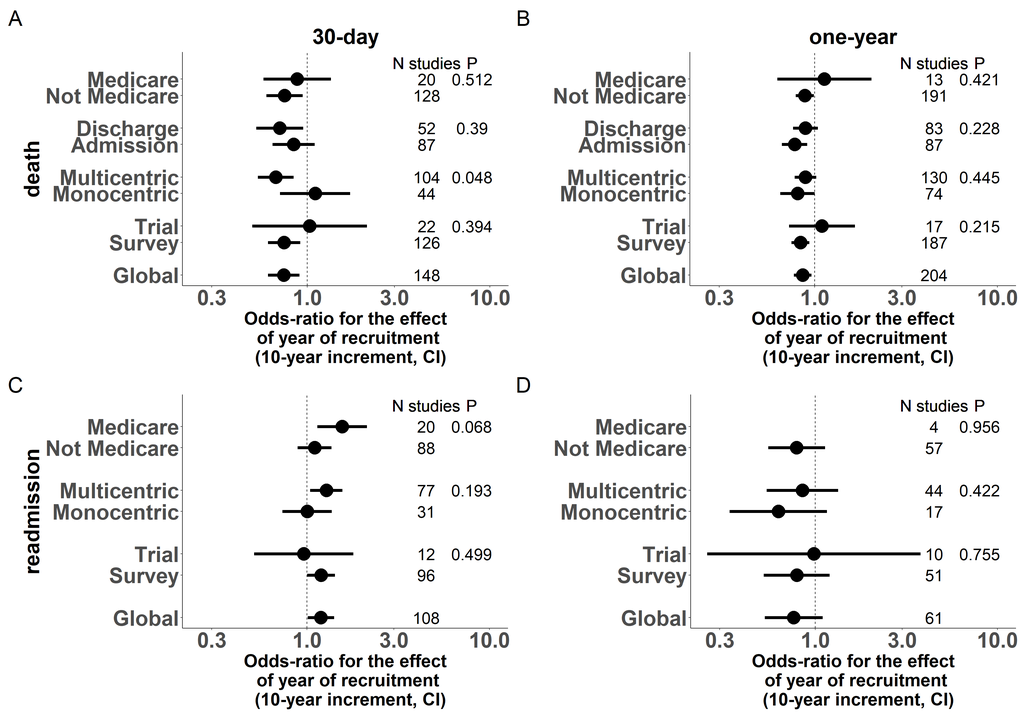

```r
figS4 <- (plot_OR_d30d + plot_OR_d1y) / (plot_OR_r30d + plot_OR_r1y) + plot_annotation(tag_levels = 'A') &
  theme(plot.tag = element_text(size = 30))
figS4
```

```r
ggsave("figures/Fig_S4_subgroup_outcomes.tiff", width = 50, height = 40, units = "cm", dpi = 300)
ggsave("figures/Fig_S4_subgroup_outcomes.jpg", width = 50, height = 40, units = "cm", dpi = 300)
```

# Subgroup analyses

We want to look at the effect of year of recruitment on 30-day and one-year death in different subgroups from clinically relevant variables accounting for the severity of AHF.

## Table S7: For 30-day all-cause mortality

```r
DATA <- DATA %>%
              mutate(AGE_fac = fct_relevel(as_factor(ifelse(AGE_bin == 0, "Age < 74 yrs", "Age >= 74 yrs")), "Age < 74 yrs"),
                     SR_fac = fct_relevel(as_factor(ifelse(SR_bin == 0, "Male ratio < 52%", "Male ratio >= 52%")), "Male ratio < 52%"),
                     SBP_fac = fct_relevel(as_factor(ifelse(SBP_bin == 0, "SBP < 135 mmHg", "SBP >= 135 mmHg")), "SBP < 135 mmHg"),
                     HR_fac = fct_relevel(as_factor(ifelse(HR_bin == 0, "HR < 87 bpm", "HR >= 87 bpm")), "HR < 87 bpm"),
                     EF_fac = fct_relevel(as_factor(ifelse(EF_bin == 0, "EF < 40%", "EF >= 40%")), "EF < 40%"))

age_d30d <- sub_OR_group_fun("number_follow_up", "TIME", "death_30_all", "AGE_fac", "Age >= 74 yrs", "Age")

SR_d30d <- sub_OR_group_fun("number_follow_up", "TIME", "death_30_all", "SR_fac", "Male ratio >= 52%", "Male ratio")

SBP_d30d <- sub_OR_group_fun("number_follow_up", "TIME", "death_30_all", "SBP_fac", "SBP >= 135 mmHg", "Systolic blood pressure")

HR_d30d <- sub_OR_group_fun("number_follow_up", "TIME", "death_30_all", "HR_fac", "HR >= 87 bpm", "Heart rate")

EF_d30d <- sub_OR_group_fun("number_follow_up", "TIME", "death_30_all", "EF_fac", "EF >= 40%", "Ejection fraction")

sub_tab_30d <- bind_rows(age_d30d, SR_d30d, SBP_d30d, HR_d30d, EF_d30d)
```

```r
flx_sub_tab_30d <-  flextable(sub_tab_30d) %>%
                    autofit() %>%
                    set_caption("Table S7: Odds-ratios (CI) and p-values for the effects of year of recruitment (10 year increment) on 30-day all-cause death in subgroups from clinically relevant variables accounting for severity of AHF") %>%
                    bold(part = "header") %>%
                    align(j = c(3:8), align = "center", part = "all") %>%
                    align(j = c(1,2), align = "left", part = "all")

flx_sub_tab_30d %>% width(width = dim(.)$widths * 10 / sum(dim(.)$widths)) # setting column width for a maximum width of 10 inches
```

Table S7: Odds-ratios (CI) and p-values for the effects of year of recruitment (10 year increment) on 30-day all-cause death in subgroups from clinically relevant variables accounting for severity of AHF

| Variable | Group | N | OR | lowCI | upCI | p | p inter |
| --- | --- | --- | --- | --- | --- | --- | --- |
| Age |  |  |  |  |  |  | 0.589 |
|  | Age < 74 yrs | 62 | 0.92 | 0.65 | 1.29 | 0.6138 |  |
|  | Age >= 74 yrs | 73 | 0.82 | 0.65 | 1.03 | 0.0876 |  |
| Male ratio |  |  |  |  |  |  | 0.2526 |
|  | Male ratio < 52% | 76 | 0.72 | 0.56 | 0.92 | 0.0092 |  |
|  | Male ratio >= 52% | 66 | 0.92 | 0.66 | 1.28 | 0.6099 |  |
| Systolic blood pressure |  |  |  |  |  |  | 0.1506 |
|  | SBP < 135 mmHg | 29 | 1.16 | 0.66 | 2.04 | 0.6092 |  |
|  | SBP >= 135 mmHg | 37 | 0.68 | 0.41 | 1.11 | 0.1199 |  |
| Heart rate |  |  |  |  |  |  | 0.1901 |
|  | HR < 87 bpm | 27 | 1.33 | 0.7 | 2.53 | 0.3755 |  |
|  | HR >= 87 bpm | 29 | 0.81 | 0.52 | 1.26 | 0.3418 |  |
| Ejection fraction |  |  |  |  |  |  | 0.416 |
|  | EF < 40% | 21 | 0.72 | 0.34 | 1.5 | 0.3752 |  |
|  | EF >= 40% | 20 | 1.12 | 0.49 | 2.57 | 0.7877 |  |

## Table S8: For one-year all-cause mortality

```r
age_d1y <- sub_OR_group_fun("number_follow_up", "TIME", "death_365", "AGE_fac", "Age >= 74 yrs", "Age")

SR_d1y <- sub_OR_group_fun("number_follow_up", "TIME", "death_365", "SR_fac", "Male ratio >= 52%", "Male ratio")

SBP_d1y <- sub_OR_group_fun("number_follow_up", "TIME", "death_365", "SBP_fac", "SBP >= 135 mmHg", "Systolic blood pressure")

HR_d1y <- sub_OR_group_fun("number_follow_up", "TIME", "death_365", "HR_fac", "HR >= 87 bpm", "Heart rate")

EF_d1y <- sub_OR_group_fun("number_follow_up", "TIME", "death_365", "EF_fac", "EF >= 40%", "Ejection fraction")

sub_tab_1y <- bind_rows(age_d1y, SR_d1y, SBP_d1y, HR_d1y, EF_d1y)
```

```r
flx_sub_tab_1y <-  flextable(sub_tab_1y) %>%
                    autofit() %>%
                    set_caption("Table S8: Odds-ratios (CI) and p-values for the effects of year of recruitment (10 year increment) on one-year all-cause death in subgroups from clinically relevant variables accounting for severity of AHF") %>%
                    bold(part = "header") %>%
                    align(j = c(3:8), align = "center", part = "all") %>%
                    align(j = c(1,2), align = "left", part = "all")

flx_sub_tab_1y %>% width(width = dim(.)$widths * 10 / sum(dim(.)$widths)) # setting column width for a maximum width of 10 inches
```

Table S8: Odds-ratios (CI) and p-values for the effects of year of recruitment (10 year increment) on one-year all-cause death in subgroups from clinically relevant variables accounting for severity of AHF

| Variable | Group | N | OR | lowCI | upCI | p | p inter |
| --- | --- | --- | --- | --- | --- | --- | --- |
| Age |  |  |  |  |  |  | 0.8849 |
|  | Age < 74 yrs | 87 | 0.93 | 0.78 | 1.11 | 0.411 |  |
|  | Age >= 74 yrs | 94 | 0.94 | 0.82 | 1.09 | 0.4168 |  |
| Male ratio |  |  |  |  |  |  | 0.5731 |
|  | Male ratio < 52% | 93 | 0.91 | 0.77 | 1.06 | 0.2285 |  |
|  | Male ratio >= 52% | 95 | 0.85 | 0.72 | 1 | 0.0506 |  |
| Systolic blood pressure |  |  |  |  |  |  | 0.2232 |
|  | SBP < 135 mmHg | 46 | 1 | 0.73 | 1.37 | 0.9967 |  |
|  | SBP >= 135 mmHg | 42 | 0.73 | 0.49 | 1.1 | 0.1284 |  |
| Heart rate |  |  |  |  |  |  | 0.8904 |
|  | HR < 87 bpm | 29 | 0.84 | 0.57 | 1.25 | 0.3935 |  |
|  | HR >= 87 bpm | 38 | 0.88 | 0.61 | 1.26 | 0.4758 |  |
| Ejection fraction |  |  |  |  |  |  | 0.2509 |
|  | EF < 40% | 41 | 0.81 | 0.58 | 1.13 | 0.2173 |  |
|  | EF >= 40% | 32 | 1.13 | 0.7 | 1.8 | 0.6192 |  |

## Table S9: For 30-day all-cause readmission

```r
age_r30d <- sub_OR_group_fun("number_follow_up", "TIME", "rehosp_30_all.cause_all", "AGE_fac", "Age >= 74 yrs", "Age")

SR_r30d <- sub_OR_group_fun("number_follow_up", "TIME", "rehosp_30_all.cause_all", "SR_fac", "Male ratio >= 52%", "Male ratio")

SBP_r30d <- sub_OR_group_fun("number_follow_up", "TIME", "rehosp_30_all.cause_all", "SBP_fac", "SBP >= 135 mmHg", "Systolic blood pressure")

HR_r30d <- sub_OR_group_fun("number_follow_up", "TIME", "rehosp_30_all.cause_all", "HR_fac", "HR >= 87 bpm", "Heart rate")

EF_r30d <- sub_OR_group_fun("number_follow_up", "TIME", "rehosp_30_all.cause_all", "EF_fac", "EF >= 40%", "Ejection fraction")

sub_tab_r30d <- bind_rows(age_r30d, SR_r30d, SBP_r30d, HR_r30d, EF_r30d)
```

```r
flx_sub_tab_r30d <-  flextable(sub_tab_r30d) %>%
                    autofit() %>%
                    set_caption("Table S9: Odds-ratios (CI) and p-values for the effects of year of recruitment (10 year increment) on 30-day all-cause readmission in subgroups from clinically relevant variables accounting for severity of AHF") %>%
                    bold(part = "header") %>%
                    align(j = c(3:8), align = "center", part = "all") %>%
                    align(j = c(1,2), align = "left", part = "all")

flx_sub_tab_r30d %>% width(width = dim(.)$widths * 10 / sum(dim(.)$widths)) # setting column width for a maximum width of 10 inches
```

Table S9: Odds-ratios (CI) and p-values for the effects of year of recruitment (10 year increment) on 30-day all-cause readmission in subgroups from clinically relevant variables accounting for severity of AHF

| Variable | Group | N | OR | lowCI | upCI | p | p inter |
| --- | --- | --- | --- | --- | --- | --- | --- |
| Age |  |  |  |  |  |  | 0.3613 |
|  | Age < 74 yrs | 41 | 1.09 | 0.82 | 1.43 | 0.5578 |  |
|  | Age >= 74 yrs | 54 | 1.28 | 1.02 | 1.59 | 0.0308 |  |
| Male ratio |  |  |  |  |  |  | 0.7202 |
|  | Male ratio < 52% | 59 | 1.17 | 0.93 | 1.47 | 0.1745 |  |
|  | Male ratio >= 52% | 41 | 1.25 | 0.93 | 1.67 | 0.1362 |  |
| Systolic blood pressure |  |  |  |  |  |  | 0.2009 |
|  | SBP < 135 mmHg | 14 | 1.13 | 0.58 | 2.2 | 0.7237 |  |
|  | SBP >= 135 mmHg | 17 | 0.69 | 0.44 | 1.07 | 0.0932 |  |
| Heart rate |  |  |  |  |  |  | 0.0595 |
|  | HR < 87 bpm | 19 | 1.18 | 0.66 | 2.1 | 0.5788 |  |
|  | HR >= 87 bpm | 7 | 0.57 | 0.32 | 1.01 | 0.0536 |  |
| Ejection fraction |  |  |  |  |  |  | 0.3368 |
|  | EF < 40% | 13 | 1.09 | 0.76 | 1.55 | 0.6448 |  |
|  | EF >= 40% | 13 | 0.76 | 0.38 | 1.54 | 0.4523 |  |

## Table S10: For one-year all-cause readmission

```r
age_r1y <- sub_OR_group_fun("number_follow_up", "TIME", "rehosp_365", "AGE_fac", "Age >= 74 yrs", "Age")

SR_r1y <- sub_OR_group_fun("number_follow_up", "TIME", "rehosp_365", "SR_fac", "Male ratio >= 52%", "Male ratio")

SBP_r1y <- sub_OR_group_fun("number_follow_up", "TIME", "rehosp_365", "SBP_fac", "SBP >= 135 mmHg", "Systolic blood pressure")

HR_r1y <- sub_OR_group_fun("number_follow_up", "TIME", "rehosp_365", "HR_fac", "HR >= 87 bpm", "Heart rate")

EF_r1y <- sub_OR_group_fun("number_follow_up", "TIME", "rehosp_365", "EF_fac", "EF >= 40%", "Ejection fraction")

sub_tab_r1y <- bind_rows(age_r1y, SR_r1y, SBP_r1y, HR_r1y, EF_r1y)
```

```r
flx_sub_tab_r1y <-  flextable(sub_tab_r1y) %>%
                    autofit() %>%
                    set_caption("Table S10: Odds-ratios (CI) and p-values for the effects of year of recruitment (10 year increment) on one-year all-cause readmission in subgroups from clinically relevant variables accounting for severity of AHF") %>%
                    bold(part = "header") %>%
                    align(j = c(3:8), align = "center", part = "all") %>%
                    align(j = c(1,2), align = "left", part = "all")

flx_sub_tab_r1y %>% width(width = dim(.)$widths * 10 / sum(dim(.)$widths)) # setting column width for a maximum width of 10 inches
```

Table S10: Odds-ratios (CI) and p-values for the effects of year of recruitment (10 year increment) on one-year all-cause readmission in subgroups from clinically relevant variables accounting for severity of AHF

| Variable | Group | N | OR | lowCI | upCI | p | p inter |
| --- | --- | --- | --- | --- | --- | --- | --- |
| Age |  |  |  |  |  |  | 0.1962 |
|  | Age < 74 yrs | 24 | 0.55 | 0.33 | 0.91 | 0.0212 |  |
|  | Age >= 74 yrs | 27 | 0.88 | 0.52 | 1.51 | 0.6434 |  |
| Male ratio |  |  |  |  |  |  | 0.9801 |
|  | Male ratio < 52% | 29 | 0.76 | 0.43 | 1.34 | 0.3479 |  |
|  | Male ratio >= 52% | 26 | 0.77 | 0.45 | 1.33 | 0.349 |  |
| Systolic blood pressure |  |  |  |  |  |  | 0.9156 |
|  | SBP < 135 mmHg | 14 | 0.9 | 0.43 | 1.91 | 0.7921 |  |
|  | SBP >= 135 mmHg | 7 | 0.97 | 0.29 | 3.32 | 0.9652 |  |
| Heart rate |  |  |  |  |  |  | 0.8495 |
|  | HR < 87 bpm | 9 | 0.86 | 0.4 | 1.87 | 0.7035 |  |
|  | HR >= 87 bpm | 7 | 0.98 | 0.3 | 3.16 | 0.9686 |  |
| Ejection fraction |  |  |  |  |  |  | 0.7554 |
|  | EF < 40% | 9 | 0.7 | 0.41 | 1.2 | 0.1963 |  |
|  | EF >= 40% | 5 | 0.83 | 0.27 | 2.49 | 0.7354 |  |

# QOS analyses

## Figure S5: Assessment of study quality

```r
a<-addmargins(table(qos$i.Representativeness.of.the.study.population,deparse.level = 2))
b<-round(a/a[4]*100,1)

a<-addmargins(table(qos$h.Inclusion.exclusion.criteria.clearly.stated))
c<-round(a/a[4]*100,1)

a<-addmargins(table(qos$g.Clinical.and.biological.assessement.of.cohort.at.baseline))
d<-round(a/a[4]*100,1)

a<-addmargins(table(qos$e.Individual.follow.up))
e<-round(a/a[4]*100,1)

a<-addmargins(table(qos$d.Loss.of.follow.up.reported))
f<-round(a/a[4]*100,1)

a<-addmargins(table(qos$b.Results.believable))
g<-round(a/a[4]*100,1)

a<-addmargins(table(qos$a.Funding.reported))
h<-round(a/a[4]*100,1)

Qos_table<-matrix(NA,7,5)
Qos_table[1,]<-c(names(qos)[2],b)
Qos_table[2,]<-c(names(qos)[3],c)
Qos_table[3,]<-c(names(qos)[4],d)
Qos_table[4,]<-c(names(qos)[6],e)
Qos_table[5,]<-c(names(qos)[7],f)
Qos_table[6,]<-c(names(qos)[9],g)
Qos_table[7,]<-c(names(qos)[10],h)

colnames(Qos_table)<-c("Parameters","high (%)", "low  (%)", "unclear  (%)", "sum  (%)")

Qos_table<-as.data.frame(Qos_table)
flx_sub_tab_Qos <-  flextable(Qos_table) %>%
                    autofit() %>%
                    set_caption("Risk of bias rate estimated by the assessment quality tool") %>%
                    bold(part = "header") %>%
                    align(j = c(2:5), align = "center", part = "all") %>%
                    align(j = c(1), align = "left", part = "all")

flx_sub_tab_Qos %>% width(width = dim(.)$widths * 10 / sum(dim(.)$widths)) # setting column width for a maximum width of 10 inches
```

Risk of bias rate estimated by the assessment quality tool

| Parameters | high (%) | low (%) | unclear (%) | sum (%) |
| --- | --- | --- | --- | --- |
| i.Representativeness.of.the.study.population | 21.4 | 67.4 | 11.2 | 100 |
| h.Inclusion.exclusion.criteria.clearly.stated | 18.6 | 66.3 | 15.1 | 100 |
| g.Clinical.and.biological.assessement.of.cohort.at.baseline | 22.5 | 67 | 10.5 | 100 |
| e.Individual.follow.up | 29.8 | 58.2 | 11.9 | 100 |
| d.Loss.of.follow.up.reported | 41.4 | 50.2 | 8.4 | 100 |
| b.Results.believable | 7.4 | 80.7 | 11.9 | 100 |
| a.Funding.reported | 30.9 | 62.8 | 6.3 | 100 |

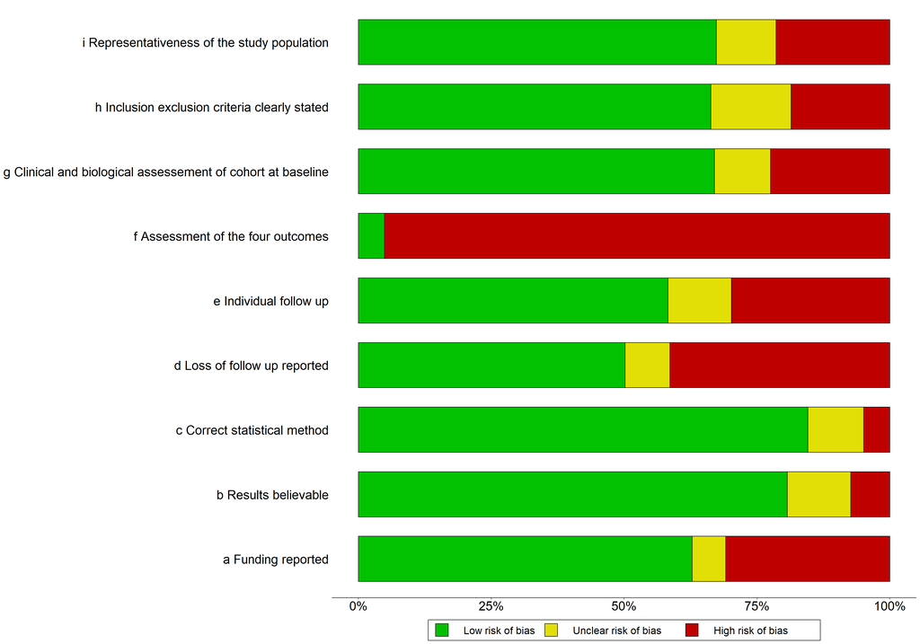

```r
figS5<-rob.summary(qos, studies = qos$Study, table = FALSE)
figS5
```

```r
ggsave("figures/Fig_S5_qos.tiff", width = 40, height = 20, units = "cm", dpi = 150)
```